# HW5 GAMENet

In this question, we will implement GAMENet proposed by Junyuan Shang et al. in the paper [GAMENet: Graph Augmented MEmory Networks for Recommending Medication Combination](https://ojs.aaai.org//index.php/AAAI/article/view/3905).

```python
import os
import dill
import random
import numpy as np
import torch
import torch.nn as nn
import torch.nn.functional as F
import math

# set seed
seed = 1234
random.seed(seed)
np.random.seed(seed)
torch.manual_seed(seed)
os.environ["PYTHONHASHSEED"] = str(seed)

# define data path
DATA_PATH = "../HW5_GAMENet-lib/data/"
```

GAMENet is a memory network, which uses external memory components to assist the deep neural networks in remembering and storing information.

At a high level, a memory network consists of the following four steps:

- **Input feature map (I)** converts the incoming input to the internal feature representation.
- **Generalization (G)** component updates old memories given new input.
- **Output feature map (O)** produces a new output in the feature representation space, given the new input and the current memory state.
- **Response component (R)** converts the output into the response format desired.

We will decompose and implement module by module

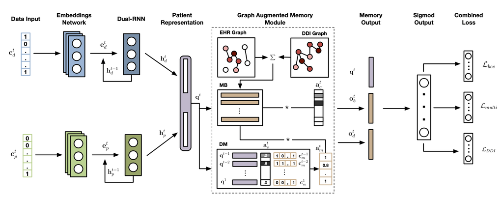

**Step1:** Data Loader. The input of the model is the multi-hot diagnosis and procedure codes. Before running the model, we should prepare the well-formatted diagnosis, procedure and medication data

**Step2:** The diagnosis and procedure data pass through two RNN networks separately. The outputs of two RNNs are then concatenated as the patient representation.

**Step3 (I):** The input of the memory network is transformed from the patient representation (by a fully connected neural network)

**Step4 (G):** Generate/update the graph memory bank (MB) and the dynamic memory table (DM)

**Step5 (O):** Read from the graph memory bank (MB) and the dynamic memory table (DM), and generate the output of the memory network

**Step6 (R):** Convert the output and predict the final results

## Step1: Data Loader [5 points]

```python
data = dill.load(open(f'{DATA_PATH}/records_final.pkl', 'rb'))
```

##### The loaded Data Format

The variable "data" is a list object, each entry is the information of one single patient

- data = [patient1, patient2, patient3, ...]

Each patient object is itself a list, enumerating each clinical visit. The length of a patient object is equal to the number of visits. Thus, each patient will have different lengths.

- patienti = [visit1, visit2, visit3, ...]

Each visit object is itself a list with three entries: diagnosis codes, procedure codes and medication codes.

- visiti = [diag_code, prod_code, med_code]

Three entries are themselves lists, enumerating the corresponding code indices in order. For example, for the first visit of the first patient, we have

- diagnosis: data[0][0][0] = [0, 1, 2, 3, 4, 5, 6, 7]
- procedure: data[0][0][1] = [0, 1, 2]
- medication: data[0][0][2] = [0, 1, 2, 3, 4, 5, 6, 7, 8, 9, 10, 11, 12, 13, 14]

```python
"""
TODO: count the vocabulary size (total types) of diag / prod / med code
"""

vocab_diag = None
vocab_prod = None
vocab_med = None

# your code here
# raise NotImplementedError
diag = set()
proc = set()
med = set()
for patient in data:
    for visit in patient:
        for d in visit[0]:
            diag.add(d)
        for p in visit[1]:
            proc.add(p)
        for m in visit[2]:
            med.add(m)

vocab_diag = len(diag)
vocab_prod = len(proc)
vocab_med = len(med)
```

```python
'''
AUTOGRADER CELL. DO NOT MODIFY THIS.
'''

assert vocab_diag == 1958, "vocabulary size of diag is wrong!"
```

## Step2: Recurrent Neural Networks (RNN) [10 points]

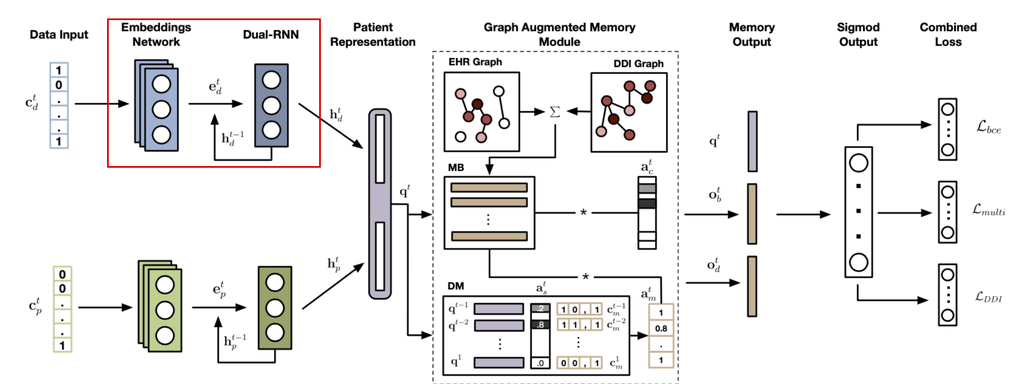

```python
class RNN(nn.Module):
    def __init__(self, vocab_size, emb_dim=16):
        super(RNN, self).__init__()
        """
        FUNCTIONALITY:
            1. embed the input medical code
            2. take the average for one visit
            3. pass to the RNN visit by visit
            4. output embedding seq for each visit
        """

        """
        TODO:
            1. build an embedding table using nn.Embedding()
                - row size: vocab_size
                - emb size: emb_size
            2. build an GRU cell using nn.GRU()
                - input dim: emb_dim
                - output dim: emb_dim
                - remember to use batch_first=True option!
        """
        self.embeddings = None
        self.rnn = None
        # your code here
        # raise NotImplementedError
        # Begin - My code
        self.embeddings = nn.Embedding(num_embeddings = vocab_size, embedding_dim = emb_dim)
        self.rnn = nn.GRU(input_size = emb_dim, hidden_size = emb_dim, batch_first = True)
        # End - My code

        self.init_weights()

    def forward(self, codes):
        """
        Input:
            codes: [[codes for visit1], [codes for visit2], ...]
                - e.g., [[0,1], [1,2]]
        Output:
            embedding seq
                - dim: (#visits, emb_dim)
        """

        emb_list = []
        for code in codes:

            """
            TODO: to use the self.embeddings
            """
            emb = None
            # your code here
            # raise NotImplementedError
            # Begin - My code
            emb = self.embeddings(torch.tensor(code))
            # End - My code

            # take the mean and make one sample per batch
            emb_mean = emb.mean(dim=0).unsqueeze(dim=0)
            emb_list.append(emb_mean)

        emb_seq = torch.cat(emb_list, dim=0).unsqueeze(dim=0)

        """
        TODO: to use the self.rnn
        """
        result = None
        # your code here
        # raise NotImplementedError
        # Begin - My code
        result, _ = self.rnn(emb_seq)
        # End - My code

        return result

    def init_weights(self):
        torch.nn.init.normal_(self.embeddings.weight)
        for param in self.rnn.parameters():
            if len(param.shape) >= 2:
                torch.nn.init.orthogonal_(param.data)
            else:
                torch.nn.init.normal_(param.data)
```

```python
'''
AUTOGRADER CELL. DO NOT MODIFY THIS.
'''

torch.manual_seed(2)
rnn = RNN(vocab_diag)
test_point = rnn([[0,1], [1,2]])[0, -1, 1].data.item()
assert round(test_point, 4) == -0.6705, "RNN is wrong!"
```

## Step3 (I): Patient query network [10 points]

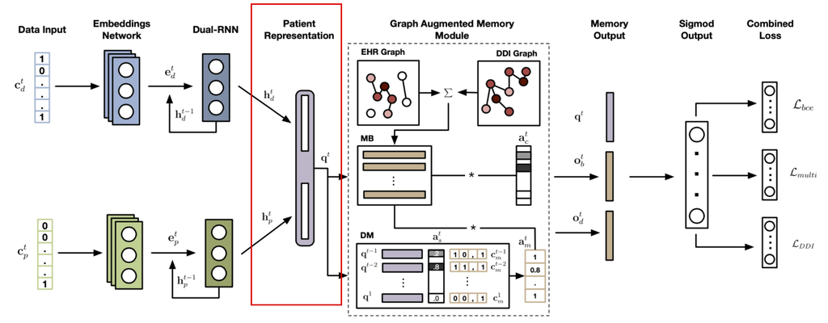

```python
class PatientQuery(nn.Module):
    def __init__(self, vocab_diag, vocab_prod, emb_dim=16):
        super(PatientQuery, self).__init__()
        """
        FUNCTIONALITY:
            1. input the embedding given by RNN
            2. output the patient representation
        """

        """
        TODO:
            1. reuse the RNN module for diagnosis code
                - use the vocab_diag
                - assign the emb_dim
            2. reuse the RNN module for procedure code
                - use the vocab_prod
                - assign the emb_dim
            3. build a linear layer using nn.Linear
                - you will concat diag and prod embedding
                - input size: 2 * emb_dim
                - output size: emb_dim
                - use bias=True option
        """
        self.rnn_diag = None
        self.rnn_prod = None
        self.linear = None
        # your code here
        # raise NotImplementedError
        # Begin - My code
        self.emb_dim_bkp = emb_dim
        self.rnn_diag = RNN(vocab_diag, emb_dim)
        self.rnn_prod = RNN(vocab_prod, emb_dim)

        self.linear = nn.Linear(in_features = 2 * emb_dim, out_features = emb_dim, bias=True)
        # End - My code

    def forward(self, codes_diag, codes_prod):
        """
        Input:
            codes_diag: [[diag codes for visit1], [diag codes for visit2], ...]
                - e.g., [[0,1], [1,2]]
            codes_prod: [[prod codes for visit1], [prod codes for visit2], ...]
                - e.g., [[0,1], [1,2]]
        output:
            query embedding:
                - size: (#visits, emd_dim)
        """

        """
        TODO: get diag and prod embedding by self.rnn_diag, self.rnn_prod
        """
        emb_diag = None
        emb_prod = None
        # your code here
        # raise NotImplementedError
        # Begin - My code
        emb_diag = self.rnn_diag(codes_diag)
        emb_prod = self.rnn_prod(codes_prod)

        emb_diag = emb_diag.view(emb_diag.shape[1], emb_diag.shape[2]) # Oth
        emb_prod = emb_prod.view(emb_prod.shape[1], emb_prod.shape[2]) # Oth
        # End - My code

        """
        TODO: concat emb_diag and emb_prod, then tranfrom by self.linear
        """
        emb_cat = None
        result = None
        # your code here
        # raise NotImplementedError
        # Begin - My code
        # emb_cat = torch.cat((emb_diag, emb_prod), dim=2).squeeze(dim=0)
        emb_cat = torch.cat((emb_diag, emb_prod), dim=1) # Oth
        result = self.linear(emb_cat)
        # End- My code

        return result
```

```python
'''
AUTOGRADER CELL. DO NOT MODIFY THIS.
'''

torch.manual_seed(2)
patient = PatientQuery(vocab_diag, vocab_prod)
test_point = patient([[0,1], [1,2]], [[0,1], [1,2]])[-1, 1].data.item()
assert round(test_point, 4) == -0.5250, "PatientQuery is wrong!"
```

## Step4 (G): generate/update MB and DM [30 points]

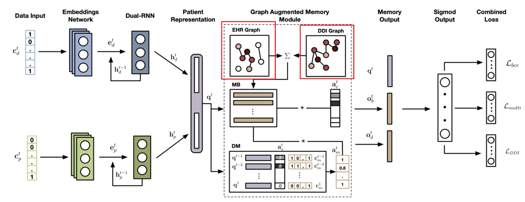

```python
class GraphConvolution(nn.Module):
    """
    Simple GCN layer, similar to https://arxiv.org/abs/1609.02907
    """

    def __init__(self, in_features, out_features, bias=True):
        super(GraphConvolution, self).__init__()
        self.in_features = in_features
        self.out_features = out_features
        self.weight = nn.Parameter(torch.FloatTensor(in_features, out_features))
        if bias:
            self.bias = nn.Parameter(torch.FloatTensor(out_features))
        else:
            self.register_parameter('bias', None)
        self.reset_parameters()

    def reset_parameters(self):
        stdv = 1. / math.sqrt(self.weight.size(1))
        self.weight.data.uniform_(-stdv, stdv)
        if self.bias is not None:
            self.bias.data.uniform_(-stdv, stdv)

    def forward(self, input, adj):
        support = torch.mm(input, self.weight)
        output = torch.mm(adj, support)
        if self.bias is not None:
            return output + self.bias
        else:
            return output

    def __repr__(self):
        return self.__class__.__name__ + ' (' \
               + str(self.in_features) + ' -> ' \
               + str(self.out_features) + ')'

class GCN(nn.Module):
    def __init__(self, vocab_med, adj, emb_dim=16):
        super(GCN, self).__init__()
        """
        FUNCTIONALITY: given the adjacency matrix, do graph convolution twice
        """

        """
        TODO:
            1 (already done). normalize the adj using self.normalize, change to torch.FloatTensor()
            2. design one graph convolution layer with GraphConvolution in Line 1
                - input size: vocab_med
                - output size: emb_dim
            3. design another graph convolution layer
                - input size: emb_dim
                - output size: emb_dim
        """
        adj = self.normalize(adj + np.eye(adj.shape[0]))
        self.adj = torch.FloatTensor(adj)

        self.gcn1 = None
        self.gcn2 = None
        # your code here
        # raise NotImplementedError
        # Begin - My code
        self.gcn1 = GraphConvolution(in_features = vocab_med, out_features = emb_dim)
        self.gcn2 = GraphConvolution(in_features = emb_dim, out_features = emb_dim)
        # End - My code

        # the initial feature
        self.x = torch.eye(vocab_med)

    def forward(self):
        """
        TODO:
            1 (already done). use self.gcn1 for the first graph convolution
                - remember to use self.adj
            2. use F.relu() as the activation function
            3. use self.gcn2
        """
        x = self.gcn1(self.x, self.adj)
        # your code here
        # raise NotImplementedError
        # Begin - My code
        x = F.relu(x)
        x = self.gcn2(x, self.adj)
        # End - My code

        return x

    def normalize(self, adj):
        adj = adj / (adj @ np.ones(adj.shape) + 1e-8)
        return adj
```

```python
class MemoryBank(nn.Module):
    def __init__(self, vocab_med, adj_ehr, adj_ddi, emb_dim=16):
        super(MemoryBank, self).__init__()
        """
        FUNCTIONALITY: conbime information from EHR graph and DDI graph
        """

        """
        TODO:
            1. use GCN for EHR graph
                - using adj_ehr
                - using emb_dim as the ouput dimension
            2. use GCN for DDI graph
                - using adj_ddi
                - using emb_dim as the ouput dimension
            3 (already done). design a learnable weight between them
        """
        self.gcn_ehr = None
        self.gcn_ddi = None
        # your code here
        # raise NotImplementedError
        # Begin - My code
        self.gcn_ehr = GCN(vocab_med, adj_ehr, emb_dim=emb_dim)
        self.gcn_ddi = GCN(vocab_med, adj_ddi, emb_dim=emb_dim)
        # End - My code

        self.weight = nn.Parameter(torch.FloatTensor(1))
        self.weight.data.uniform_(-0.1, 0.1)

    def forward(self):
        """
        TODO:
            1. get ehr graph feature
                - using .forward() function
            2. get ddi graph feature
                - using .forward() function
            3 (already done). get weighted information
        """

        # TODO
        info_ehr = None
        info_ddi = None
        # your code here
        # raise NotImplementedError
        # Begin - My code
        info_ehr = self.gcn_ehr()
        info_ddi = self.gcn_ddi()
        # End - My code

        info_comb = info_ehr - info_ddi * self.weight

        return info_comb
```

```python
'''
AUTOGRADER CELL. DO NOT MODIFY THIS.
'''

torch.manual_seed(1234)

ehr_adj_path = f'{DATA_PATH}/adj_ehr.pkl'
ddi_adj_path = f'{DATA_PATH}/adj_ddi.pkl'
adj_ehr = dill.load(open(ehr_adj_path, 'rb'))
adj_ddi = dill.load(open(ddi_adj_path, 'rb'))

MB = MemoryBank(vocab_med, adj_ehr, adj_ddi)
test_point = MB()
assert test_point.shape == (131, 16), "MemoryBank is wrong!"
assert round(test_point[0, 2].data.item(), 4) == -0.1531, "MemoryBank is wrong!"
```

```python
class DynamicMemory(nn.Module):
    def __init__(self, vocab_med):
        super(DynamicMemory, self).__init__()
        """
        FUNCTIONALITY: generate a historical mapping: query embedding -> multi-hot medication vector
        """
        self.vocab_med = vocab_med

    def forward(self, queries, codes_med):
        """
        Input:  queries
                    - this is the historical query embedding, given by PatientQuery Module
                    - size: (#visits - 1, emb_dim), delete the current query
                codes_med
                    - this is the historical groud truth med vector
                    - format: a list of length (#visits - 1)
        """

        DM_key = queries
        DM_value = np.zeros((queries.shape[0], self.vocab_med))

        """
        TODO: transform codes_med to multi-hot and filling DM_value row by row (visit by visit)
        """
        # your code here
        # raise NotImplementedError
        # Begin - My code
        # for idx in range(queries.shape[0]):
        for idx in range(len(codes_med)):
            # print(len(DM_value[idx]))
            # print(codes_med[idx])
            # print("-------")
            DM_value[idx][codes_med[idx]] = 1
        # End - My code

        # use torch.FloatTensor for DM_value
        DM_value = torch.FloatTensor(DM_value)

        return DM_key, DM_value
```

```python
'''
AUTOGRADER CELL. DO NOT MODIFY THIS.
'''

torch.manual_seed(1234)

patientquery = PatientQuery(vocab_diag, vocab_prod)
queries = patientquery([[0,1], [1,2]], [[0,1], [1,2]])

DM = DynamicMemory(vocab_med)
DM_key, DM_value = DM(queries, [[1,2,3,4], [1,2,5,7]])

assert DM_key.shape == (2, 16), "DynamicMemory is wrong!"
assert DM_value[0, 4] == 1, "DynamicMemory is wrong!"
assert DM_value[0, 5] == 0, "DynamicMemory is wrong!"
```

## Step5 (O): Output of the Memory Network [10 points]

- fact1: the query
- fact2: the result from querying MB
- fact3: the result from querying DM

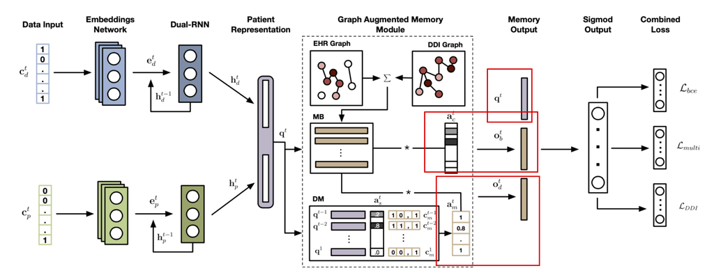

```python
class Fact1(nn.Module):
    def __init__(self, queries):
        super(Fact1, self).__init__()
        """
        FUNCTIONALITY: extract the final embedding from input queries, q^t
        """
        self.queries = queries

    def forward(self):
        """
        TODO: assign the last embedding to result
                - final size: (1, emb_dim)
                - make sure the output size is **not** a vector format (emb_dim,)
        """
        result = None
        # your code here
        # raise NotImplementedError
        # Begin - My code
        # result = self.queries[-1].reshape(1, -1)
        result = self.queries[-1].unsqueeze(dim = 0) # Oth
        # End - My code

        return result


class Fact2(nn.Module):
    def __init__(self, query, MB):
        super(Fact2, self).__init__()
        """
        FUNCTIONALITY: get attention information from MB, o^t_b
        Input:
            query
                - this is the last embedding
            MB
                - is the memory bank
        """
        self.query = query
        self.MB = MB

    def forward(self):
        """
        TODO:
            1. get the attention weight between query and each row of MB, assing to attn_score
                - use torch.mm()
                - tip: need to transpose MB, using MB.t()
            2. use F.softmax(, dim=1) to compute the attention matrix, attn_matrix
            3. get the final result from attn_matrix and MB
                - use torch.mm(,)
        """
        attn_score = None
        attn_matrix = None
        result = None
        # your code here
        # raise NotImplementedError
        # Begin - My code
        attn_score = torch.mm(self.query, self.MB.t())
        attn_matrix = F.softmax(attn_score, dim=1)
        result = torch.mm(attn_matrix, self.MB)
        # End - My code

        return result

class Fact3(nn.Module):
    def __init__(self, query, MB, DM_key, DM_value):
        super(Fact3, self).__init__()
        """
        FUNCTIONALITY: similar to Fact2, get information from the DM, o_d^t
        """
        self.query = query
        self.MB = MB
        self.DM_key = DM_key
        self.DM_value = DM_value

    def forward(self):
        attn = F.softmax(torch.mm(self.query, self.DM_key.t()), dim=1)
        value = torch.mm(attn, self.DM_value)
        out = torch.mm(value, self.MB)
        return out
```

```python
'''
AUTOGRADER CELL. DO NOT MODIFY THIS.
'''
torch.manual_seed(1234)

MB = MemoryBank(vocab_med, adj_ehr, adj_ddi)
fact1 = Fact1(queries).forward()
fact2 = Fact2(fact1, MB()).forward()
fact3 = Fact3(fact2, MB(), DM_key, DM_value).forward()

assert fact1.shape == (1,16), "fact1 is wrong!"
assert fact2.shape == (1,16), "fact2 is wrong!"
assert fact3.shape == (1,16), "fact3 is wrong!"
assert round(fact1[0, 2].data.item(), 4) == -0.2662, "fact1 is wrong!"
assert round(fact2[0, 2].data.item(), 4) == -0.1532, "fact2 is wrong!"
assert round(fact3[0, 2].data.item(), 4) == -0.6122, "fact3 is wrong!"
```

## Step6 (R): predict the medications [10 points]

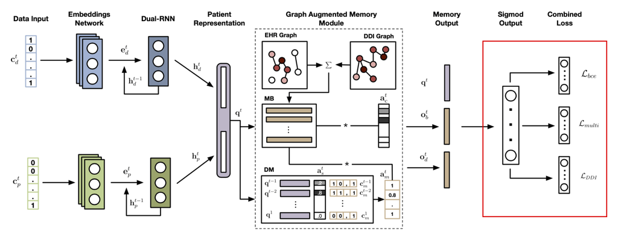

```python
class OutNet(nn.Module):
    def __init__(self, vocab_med, emb_dim=16):
        super(OutNet, self).__init__()
        """
        FUNCTIONALITY: combine fact1, fact2, fact3 to do final prediction
        """

        """
        TODO:
            1. build the first linear layer
                - input size: 3 * emb_dim
                - end size: 2 * emb_dim
                - use bias=True option
            2. build the second linear layer
                - input size: 2 * emb_dim
                - end size: vocab_med
                - use bias=True option
        """
        self.fc1 = None
        self.fc2 = None
        # your code here
        # raise NotImplementedError
        # Begin - My code
        self.fc1 = nn.Linear(in_features = 3 * emb_dim, out_features = 2 * emb_dim, bias=True)
        self.fc2 = nn.Linear(in_features = 2 * emb_dim, out_features = vocab_med, bias=True)
        # End - My code

    def forward(self, fact1, fact2, fact3):
        """
        Input:
            fact1, fact2, fact3:
                - three facts q^t, o^t_b, o^t_d
                - each size: (1, emb_dim)
        """

        """
        TODO:
            1. concat fact1, fact2, fact3, and assign to memory_out
                - size: (1, 3 * emb_dim)
            2. pass through the first linear layer
            3. use F.relu() as the activation
            3. pass through the second linear layer
        """
        memory_out = None
        result = None
        # your code here
        # raise NotImplementedError
        # Begin - My code
        memory_out = torch.cat((fact1, fact2, fact3), dim=1)
        result = self.fc1(memory_out)
        result = F.relu(result)
        result = self.fc2(result)
        # End - My code

        return result
```

```python
'''
AUTOGRADER CELL. DO NOT MODIFY THIS.
'''
torch.manual_seed(1234)

outnet = OutNet(vocab_med)
output = outnet(fact1, fact2, fact3)
assert round(output[0, 2].data.item(), 4) == -0.0463
```

## Overall GAMENet model [10 points]

```python
# please stack all the modules together

class GAMENet(nn.Module):
    def __init__(self, vocab_diag, vocab_prod, vocab_med, adj_ehr, adj_ddi, emb_dim=128):
        super(GAMENet, self).__init__()
        """
        FUNCTIONALITY: integrate the whole model together
        """

        """
        TODO:
            1. build a patient query network
                - PatientQuery
                - use vocab_diag, vocab_prod, emb_dim
            2. build a memory bank
                - MemoryBank
                - use vocab_med, adj_ehr, adj_ddi, emb_dim
            3. build a dynamic memory
                - DynamicMemory
                - use vocab_med
            4. build a output network
                - OutNet
                - vocab_med, emb_dim
        """
        self.patient = None
        self.memorybank = None
        self.dynamicmemory = None
        self.outnet = None
        # your code here
        # raise NotImplementedError
        # Begin - My code
        self.patient = PatientQuery(vocab_diag, vocab_prod, emb_dim=emb_dim)
        self.memorybank = MemoryBank(vocab_med, adj_ehr, adj_ddi, emb_dim=emb_dim)
        self.dynamicmemory = DynamicMemory(vocab_med)
        self.outnet = OutNet(vocab_med, emb_dim)
        # End - My code

    def forward(self, codes_diag, codes_prod, codes_med):
        """
        input:
            codes_diag
                - a list of length #visits
                - each element is also itself a list
            codes_prod
                - a list of length #visits
                - each element is also itself a list
            codes_med
                - a list of length #visits - 1
                - each element is also itself a list
        """

        # get patient query embedding (#visit, emb_dim*2)
        queries = self.patient(codes_diag, codes_prod)

        """
        TODO:
            1. build a memory bank, assign to MB
                - use self.memorybank
            2. build a dynamic memory, assign to DM_key and DM_value
                - use self.dynamicmemory
                - use queries and codes_med as features
        """
        MB = None
        DM_key, DM_value = None, None
        # your code here
        # raise NotImplementedError
        # Begin - My code
        MB = self.memorybank()
        DM = DynamicMemory(vocab_med)
        DM_key, DM_value = self.dynamicmemory(queries, codes_med)
        # End - My code

        # extract three memory outputs, assign to fact1, fact2, fact3
        fact1 = Fact1(queries)()
        fact2 = Fact2(fact1, MB)()
        fact3 = Fact3(fact1, MB, DM_key, DM_value)()

        # get the final output
        result = self.outnet(fact1, fact2, fact3)

        return result
```

```python
# ### Self code

# torch.manual_seed(1234)

# model = GAMENet(vocab_diag, vocab_prod, vocab_med, adj_ehr, adj_ddi)
# output = model([[0,1], [1,2], [4,5]], [[0,1], [1,2], [5,7]], [[0,1], [2,5]])

# print(output)
# print(round(output[0, 2].data.item(), 4))
```

```python
'''
AUTOGRADER CELL. DO NOT MODIFY THIS.
'''
torch.manual_seed(1234)

model = GAMENet(vocab_diag, vocab_prod, vocab_med, adj_ehr, adj_ddi)
output = model([[0,1], [1,2], [4,5]], [[0,1], [1,2], [5,7]], [[0,1], [2,5]])

assert output.shape == (1, vocab_med)
assert round(output[0, 2].data.item(), 4) == -0.0347, "GAMENet is wrong!"
```

## Training and Inferencing [15 points]

```python
import random
random.seed(seed)

tmp = data.copy()
random.shuffle(tmp)

# 80%: 20% split training and test sets randomly
train_set = tmp[:int(len(data)*0.8)]
test_set = tmp[int(len(data)*0.8):]
```

```python
%%time

model = GAMENet(vocab_diag, vocab_prod, vocab_med, adj_ehr, adj_ddi)
optimizer = torch.optim.Adam(model.parameters(), lr=1e-3)

def dataFormatter(patient_list):

    diag_list, prod_list, med_list = [], [], []
    for diag, prod, med in patient_list:
        diag_list.append(diag)
        prod_list.append(prod)
        med_list.append(med)

    target = np.zeros((1, vocab_med))
    target[0, med_list[-1]] = 1
    return diag_list, prod_list, med_list[:-1], torch.FloatTensor(target)

from sklearn.metrics import accuracy_score

def test(test_set):
    model.eval()
    pred_list, target_list = [], []
    for patient in test_set:
        for idx, visit in enumerate(patient):
            codes_diag, codes_prod, codes_med, target = dataFormatter(patient[:idx+1])
            pred = model(codes_diag, codes_prod, codes_med).detach().cpu().numpy()[0]
            pred[pred >= 0.5] = 1; pred[pred < 0.5] = 0
            pred_list += pred.tolist(); target_list += target.numpy().tolist()[0]
    return pred_list, target_list

def train(train_set):
    for i in range(2):
        model.train()
        for patient in train_set:
            loss = 0
            for idx, visit in enumerate(patient):
                # get the training data and target of bce loss
                codes_diag, codes_prod, codes_med, target = dataFormatter(patient[:idx+1])
                # get the target of multilabel_margin_loss
                multi_target = np.full((1, vocab_med), -1)
                for idx, item in enumerate(visit[2]):
                    multi_target[0][idx] = item
                multi_target = torch.LongTensor(multi_target)

                """
                TODO: get the output of the model, assign to pred
                """
                pred = None
                # your code here
                # raise NotImplementedError
                # Begin - My code
                pred = model(codes_diag, codes_prod, codes_med)
                # End - My code

                loss += F.binary_cross_entropy_with_logits(pred, target) + \
                                    F.multilabel_margin_loss(torch.sigmoid(pred), multi_target)

            """
            TODO:
                1. set zero grad to the optimizer
                2. backward loss
                3. make one step of the optimizer
            """
            # your code here
            # raise NotImplementedError
            # Begin - My code
            optimizer.zero_grad()
            loss.backward()
            optimizer.step()
            # End - My code

        # use the first 100 test patients to compute intermediate accuracy
        print(accuracy_score(*test(test_set[:100])))

# train the model with first 500 patients
# feel free to change the number of training patients
train(train_set[:500])
```

```
0.8267275575852528
0.8171939064635488
CPU times: user 28.7 s, sys: 218 ms, total: 28.9 s
Wall time: 14.6 s
```

```python
'''
AUTOGRADER CELL. DO NOT MODIFY THIS.
'''
```

```
'\nAUTOGRADER CELL. DO NOT MODIFY THIS.\n'
```